# Practical Machine Learning - Exercise classification

chris-FR-GitHub

19 Janvier 2019

## Synopsis

Today, a large number of devices such as Jawbone Up, Nike FuelBand, and Fitbit it can collect large amount of data about personal activity relatively inexpensively.  
In this project, we will try to use the data collected from accelerometers on the belt, forearm, arm, and dumbell of 6 participants to predict the manner in which they did the exercise.  
We will test different models and pick the best one to predict the class of 20 additional records.

## Data

We used and copied the 2 following data files to the current directory :  
- training data : https://d396qusza40orc.cloudfront.net/predmachlearn/pml-training.csv  
- test data : https://d396qusza40orc.cloudfront.net/predmachlearn/pml-testing.csv  
The original data from this project comes from this source: http://groupware.les.inf.puc-rio.br/har.

```r
# Load the R libraries
library(caret, warn.conflicts = TRUE)
library(tidyverse, warn.conflicts = TRUE)
```

### Load the Data

From a first file load and summary, we found that a the files contains “NA” and “#DIV/0!”. We will convert these values to NAs.

```r
# Load the CSV files
pmlTraining <- read.csv("pml-training.csv", header=TRUE, na.strings = c("NA","","#DIV/0!"))
pmlTesting <- read.csv("pml-testing.csv", header=TRUE, na.strings = c("NA","","#DIV/0!"))
```

The trainData dataset contains **19622** rows and the testData dataset contains **20** rows. Each dataset contains **160** columns.

### Quick Exploratory analysis

The summary function output has been set in appendix.

```r
# summary(pmlTraining)
# list the levels for the classe factor
levels(pmlTraining$classe)
```

```
## [1] "A" "B" "C" "D" "E"
```

```r
# summarize the classe column distribution
percentage <- prop.table(table(pmlTraining$classe)) * 100
cbind('Count'=table(pmlTraining$classe), '%'=percentage)
```

```
##   Count        %
## A  5580 28.43747
## B  3797 19.35073
## C  3422 17.43961
## D  3216 16.38977
## E  3607 18.38243
```

```r
table(NAs=colSums(is.na(pmlTraining)))
```

```
## NAs
##     0 19216 19217 19218 19220 19221 19225 19226 19227 19248 19293 19294
##    60    67     1     1     1     4     1     4     2     2     1     1
## 19296 19299 19300 19301 19622
##     2     1     4     2     6
```

These NAs do not seem to be specific to an exercise class (ex : an exercise not using a specific devise). We will remove these columns from our predictors.

```r
table(pmlTraining$classe, is.na(pmlTraining$amplitude_roll_forearm))
```

```
##
##     FALSE TRUE
##   A   109 5471
##   B    79 3718
##   C    70 3352
##   D    69 3147
##   E    79 3528
```

## Clean the data

We will remove the column containings the high number of NAs, and the first 7 columns that are the experiments (user / date / …) informations.

```r
iNAsColumn <- which(colSums(is.na(pmlTraining))>19000)
pmlTrainingClean <- pmlTraining[,-iNAsColumn]
pmlTrainingClean <- pmlTrainingClean[,-c(1:7)]
```

# Build models

## Split the train dataset in training and validation datasets

```r
# Reproducibility
set.seed(123)
# pick 80% of the rows in the original dataset
inTrain <- createDataPartition(pmlTrainingClean$classe, p=0.80, list=FALSE)
# 80% of the data to train the models
training <- pmlTrainingClean[inTrain,]
# 20% of the data for validation
validation <- pmlTrainingClean[-inTrain,]

dim(training)
```

```
## [1] 15699    53
```

## Test different models

```r
nbmodels <- length(unique(modelLookup()[modelLookup()$forClass,c(1)]))
```

Caret has **190** classification models. We are going to test 5 models from the course.

We will use 5-fold cross validation.

```r
trControl <- trainControl(method="cv", number=5)
metric <- "Accuracy"
```

Train different models (using the same seed each time).

```r
# Tree
set.seed(123)
fit.rpart <- train(classe~., data=training, method="rpart", metric=metric, trControl=trControl)

# Random Forest
set.seed(123)
fit.rf <- train(classe~., data=training, method="rf", metric=metric, trControl=trControl)

# Boosting
set.seed(123)
fit.boosting <- train(classe~., data=training, method="gbm", metric=metric,
                      trControl=trControl, verbose=FALSE)

# Model base prediction: LDA, NB
set.seed(123)
fit.lda <- train(classe~., data=training, method="lda", metric=metric, trControl=trControl)

set.seed(123)
fit.nb <- train(classe~., data=training, method="nb", metric=metric, trControl=trControl)
```

We Compare the models using the resamples caret function.

```r
# Compare algorithms usi,ng the resamples caret function
results <- resamples(list(rpart=fit.rpart,
                          rf=fit.rf, boosting=fit.boosting,
                          lda=fit.lda, nb=fit.nb))

summary(results)
```

```
##
## Call:
## summary.resamples(object = results)
##
## Models: rpart, rf, boosting, lda, nb
## Number of resamples: 5
##
## Accuracy
##               Min.   1st Qu.    Median      Mean   3rd Qu.      Max. NA's
## rpart    0.4877428 0.4914013 0.4998408 0.5116952 0.5226259 0.5568652    0
## rf       0.9910800 0.9910856 0.9923591 0.9928660 0.9945825 0.9952229    0
## boosting 0.9563833 0.9592486 0.9598598 0.9602526 0.9604844 0.9652866    0
## lda      0.6864245 0.7016874 0.7021344 0.7025905 0.7029608 0.7197452    0
## nb       0.7314431 0.7347978 0.7434672 0.7427859 0.7456224 0.7585987    0
##
## Kappa
##               Min.   1st Qu.    Median      Mean   3rd Qu.      Max. NA's
## rpart    0.3291271 0.3352490 0.3472442 0.3669742 0.3768489 0.4464020    0
## rf       0.9887176 0.9887204 0.9903344 0.9909754 0.9931474 0.9939574    0
## boosting 0.9448363 0.9484271 0.9492318 0.9497139 0.9499965 0.9560778    0
## lda      0.6038315 0.6224983 0.6227991 0.6236755 0.6242504 0.6449985    0
## nb       0.6564529 0.6603494 0.6712547 0.6718662 0.6800181 0.6912562    0
```

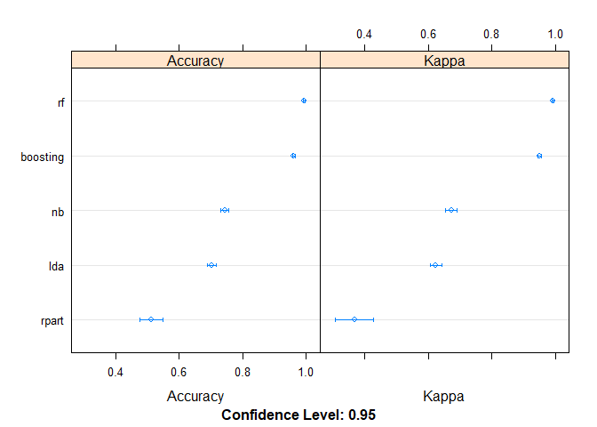

```r
dotplot(results)
```

The random forest model seem to have the better results with an average accuracy above 99.2%.

## Check the RF model

```r
print(fit.rf)
```

```
## Random Forest
##
## 15699 samples
##    52 predictor
##     5 classes: 'A', 'B', 'C', 'D', 'E'
##
## No pre-processing
## Resampling: Cross-Validated (5 fold)
## Summary of sample sizes: 12561, 12559, 12558, 12560, 12558
## Resampling results across tuning parameters:
##
##   mtry  Accuracy   Kappa
##    2    0.9928660  0.9909754
##   27    0.9919740  0.9898475
##   52    0.9870059  0.9835611
##
## Accuracy was used to select the optimal model using the largest value.
## The final value used for the model was mtry = 2.
```

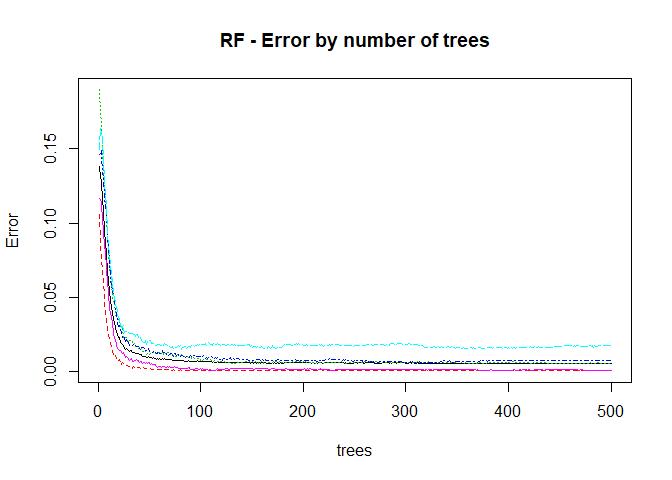

```r
plot(fit.rf$finalModel,main="RF - Error by number of trees")
```

The best model seems to use the mtry equal to 2. From the graph, the optimum number of tree seem to be 50 or 100. There is no gain with more trees.

## Tune the RF model

We will try to tune the RF model using a grid search on the mtry parameters.

```r
set.seed(123)
trControl <- trainControl(method="repeatedcv", number=5, repeats=3, search="grid")
tuneGrid <- expand.grid(.mtry=c(1:15))
fit.gridsearch <- train(classe~., data=training, method="rf",
                       metric=metric, tuneGrid=tuneGrid,
                       trControl=trControl,
                       ntree=100)
print(fit.gridsearch)
```

```
## Random Forest
##
## 15699 samples
##    52 predictor
##     5 classes: 'A', 'B', 'C', 'D', 'E'
##
## No pre-processing
## Resampling: Cross-Validated (5 fold, repeated 3 times)
## Summary of sample sizes: 12561, 12559, 12558, 12560, 12558, 12558, ...
## Resampling results across tuning parameters:
##
##   mtry  Accuracy   Kappa
##    1    0.9873029  0.9839363
##    2    0.9916981  0.9894972
##    3    0.9923351  0.9903032
##    4    0.9927596  0.9908407
##    5    0.9932481  0.9914588
##    6    0.9933967  0.9916466
##    7    0.9938214  0.9921840
##    8    0.9937364  0.9920765
##    9    0.9936302  0.9919423
##   10    0.9937364  0.9920767
##   11    0.9936939  0.9920226
##   12    0.9935241  0.9918081
##   13    0.9933116  0.9915390
##   14    0.9938001  0.9921570
##   15    0.9935665  0.9918615
##
## Accuracy was used to select the optimal model using the largest value.
## The final value used for the model was mtry = 7.
```

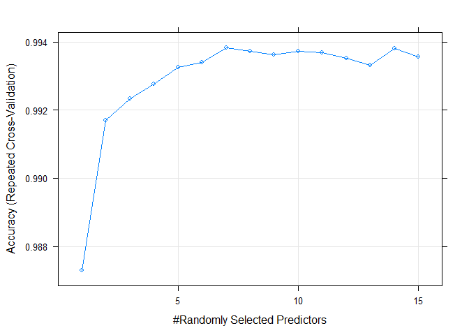

```r
plot(fit.gridsearch)
```

The best value for mtry seems to be 7 for an accuracy of 99.4%.

## Validation

```r
# predict the result on the validation dataset
predict.rf <- predict(fit.gridsearch,newdata=validation)
conf.rf <- confusionMatrix(validation$classe,predict.rf)
```

```r
conf.rf$table
```

```
##           Reference
## Prediction    A    B    C    D    E
##          A 1115    1    0    0    0
##          B    7  749    3    0    0
##          C    0    4  679    1    0
##          D    0    0   11  632    0
##          E    0    0    0    1  720
```

# Compute the class for the quiz

```r
predict.quiz <- predict(fit.gridsearch,newdata=pmlTesting)
predict.quiz
```

```
##  [1] B A B A A E D B A A B C B A E E A B B B
## Levels: A B C D E
```

# Appendix

Summary:

```r
summary(pmlTraining)
```

[output not shown]

[output cut: 313 more lines]

[output not shown]